# 3. laboratorijska vježba

Multivarijatna analiza podataka

ak. god. 2021/2022

## 1. Uvod i upute za predaju

Cilj ove laboratorijske vježbe je primijeniti osnovne koncepte multivarijatne analize podataka, istražiti podatke te ispitati hipoteze. Preduvjet za rješavanje vježbe je osnovno znanje programskog jezika *R* i rad s *R Markdown* dokumentima. Sama vježba je koncipirana kao projekt u kojem istražujete i eksperimentirate koristeći dane podatke - ne postoji nužno samo jedan točan način rješavanja svakog podzadatka.

Rješavanje vježbe svodi se na čitanje uputa u tekstu ovog dokumenta, nadopunjavanje blokova kôda (možete dodavati i dodatne blokove kôda ukoliko je potrebno) i ispisivanje rezultata (u vidu ispisa iz funkcija, tablica i grafova). Vježbu radite samostalno, a svoje rješenje branite na terminima koji su vam dodijeljeni u kalendaru. Pritom morate razumjeti teorijske osnove u okviru onoga što je obrađeno na predavanjima i morate pokazati da razumijete sav kôd koji ste napisali.

Vaše rješenje potrebno je predati u sustav *Moodle* u obliku dvije datoteke:

1. Ovaj .Rmd dokument s Vašim rješenjem (naziva IME_PREZIME_JMBAG.rmd),
2. PDF ili HTML dokument kao izvještaj generiran iz vašeg .Rmd rješenja (također naziva IME_PREZIME_JMBAG).

Rok za predaju je **7. lipnja 2022. u 23:59h**. **Jedan od uvjeta za prolaz predmeta je minimalno ostvarenih 50% bodova na svim laboratorijskim vježbama. Nadoknade laboratorijskih vježbi neće biti organizirane.** Za sva dodatna pitanja svakako se javite na email adresu predmeta: *map@fer.hr*.

## 2. Podatkovni skup

U ovoj laboratorijskoj vježbi analizirat ćemo skup podataka s najpoznatijim klasičnim skladbama prema glasovima korisnika stranice [classicalmusiconly.com](https://classicalmusiconly.com/). Varijable su redom:

- `title` — naziv skladbe
- `composer` — ime skladatelja
- `category` — kategorija skladbe
- `year` — godina kada je skladba napisana
- `stars` — broj glasova (koliko korisnika je označilo skladbu kao favorit)

Varijable `composer` i `category` treba tretirati kao da se radi o kategorijskim varijablama.

**Napomena:** ako koristite funkciju `factor` za modeliranje kategorijskih varijabli, tada je potrebno nakon filtriranja skupa podataka ponovno pozvati `factor` nad preostalim vrijednostima kategorijske varijabli — u suprotnom će izbačene vrijednosti ostati zapamćene, što će davati nepregledne rezultate.

## 2.1. Predobrada i analiza podataka

Učitajte datoteku `classical.tsv` i proučite podatke.

```r
df <- read.csv("classical.tsv", sep = "\t")
df_tmp <- df[,]
head(df)
```

|  | rank | title | composer | category | year | stars |
| --- | --- | --- | --- | --- | --- | --- |
| 1 | 1 | The Four Seasons (Le Quattro Stagioni) | Antonio Vivaldi | Violin Concerto | 1723 | 2515 |
| 2 | 2 | Requiem in D Minor, K. 626 | Wolfgang Amadeus Mozart | Mass / Requiem | 1791 | 2122 |
| 3 | 3 | Symphony No. 9 in D Minor, Op. 125 | Ludwig van Beethoven | Symphony | 1824 | 2084 |
| 4 | 4 | Nocturnes | Frédéric Chopin | Piano Sonata | 1846 | 1999 |
| 5 | 5 | Swan Lake, Op. 20 | Pyotr Ilyich Tchaikovsky | Ballet | 1876 | 1335 |
| 6 | 6 | Toccata and Fugue in D Minor, BWV 565 | Johann Sebastian Bach | Organ | NA | 1311 |

```r
#df[!complete.cases(df),]
head(df)
```

|  | rank | title | composer | category | year | stars |
| --- | --- | --- | --- | --- | --- | --- |
| 1 | 1 | The Four Seasons (Le Quattro Stagioni) | Antonio Vivaldi | Violin Concerto | 1723 | 2515 |
| 2 | 2 | Requiem in D Minor, K. 626 | Wolfgang Amadeus Mozart | Mass / Requiem | 1791 | 2122 |
| 3 | 3 | Symphony No. 9 in D Minor, Op. 125 | Ludwig van Beethoven | Symphony | 1824 | 2084 |
| 4 | 4 | Nocturnes | Frédéric Chopin | Piano Sonata | 1846 | 1999 |
| 5 | 5 | Swan Lake, Op. 20 | Pyotr Ilyich Tchaikovsky | Ballet | 1876 | 1335 |
| 6 | 6 | Toccata and Fugue in D Minor, BWV 565 | Johann Sebastian Bach | Organ | NA | 1311 |

```r
print(ncol(df))
```

```
## [1] 6
```

```r
print(nrow(df))
```

```
## [1] 2415
```

Proučite koliki je **ukupan broj skladbi po pojedinom skladatelju**, te koliki je **ukupan broj skladbi po pojedinoj kategoriji**. **Ispišite** ih poredano silazno po broju skladbi.

```r
df %>% count(composer, sort=TRUE)
```

| composer | n |
| --- | --- |
| Wolfgang Amadeus Mozart | 85 |
| Ludwig van Beethoven | 81 |
| Johann Sebastian Bach | 73 |
| Johannes Brahms | 64 |
| Franz Schubert | 62 |
| Joseph Haydn | 57 |
| Robert Schumann | 48 |
| Claude Debussy | 38 |
| Dmitri Shostakovich | 38 |
| Béla Bartók | 35 |

[output cut: 282 more lines]

```r
df %>% count(category, sort=TRUE)
```

| category | n |
| --- | --- |
| Unsorted Orchestral | 321 |
| Piano Sonata | 290 |
| Symphony | 266 |
| Opera | 201 |
| Choral orchestral | 129 |
| String Quartet | 129 |
| Lieder / Song | 123 |
| Piano Concerto | 106 |
| Chant | 82 |
| Violin Concerto | 82 |

[output cut: 29 more lines]

**Ispišite** imena prvih deset skladatelja čije skladbe imaju **najveći ukupan broj glasova**, te prvih deset skladatelja čije skladbe imaju **najveći prosječan broj glasova**.

```r
df %>% group_by(composer) %>% summarise(sum_stars = sum(stars))  %>% arrange(desc(sum_stars)) %>% top_n(10)
```

| composer | sum_stars |
| --- | --- |
| Ludwig van Beethoven | 11797 |
| Wolfgang Amadeus Mozart | 9879 |
| Johann Sebastian Bach | 9264 |
| Pyotr Ilyich Tchaikovsky | 5790 |
| Johannes Brahms | 4274 |
| Frédéric Chopin | 4176 |
| Antonio Vivaldi | 2677 |
| Antonín Dvořák | 2617 |
| Maurice Ravel | 2122 |
| Claude Debussy | 2086 |

```r
df %>% group_by(composer) %>% summarise(mean_stars = mean(stars))  %>% arrange(desc(mean_stars)) %>% top_n(10)
```

| composer | mean_stars |
| --- | --- |
| Johann Pachelbel | 384.5000 |
| Gregorio Allegri | 219.0000 |
| Georges Bizet | 209.0000 |
| Pyotr Ilyich Tchaikovsky | 186.7742 |
| Frédéric Chopin | 181.5652 |
| Antonio Vivaldi | 178.4667 |
| Erik Satie | 158.0000 |
| Richard Wagner | 151.3333 |
| Ludwig van Beethoven | 145.6420 |
| George Gershwin | 127.3333 |

Iz podataka **uklonite** sve skladbe čiji skladatelji se pojavljuju vrlo rijetko (npr. manje od 5–10 puta). Zatim, uklonite sve skladbe čija kategorija se pojavljuje vrlo rijetko (npr. manje od 5–10 puta).

```r
df_n_greater_10 <- (df %>% count(composer, sort=TRUE) %>% filter(n > 10))
df_n_greater_10
```

| composer | n |
| --- | --- |
| Wolfgang Amadeus Mozart | 85 |
| Ludwig van Beethoven | 81 |
| Johann Sebastian Bach | 73 |
| Johannes Brahms | 64 |
| Franz Schubert | 62 |
| Joseph Haydn | 57 |
| Robert Schumann | 48 |
| Claude Debussy | 38 |
| Dmitri Shostakovich | 38 |
| Béla Bartók | 35 |

[output cut: 49 more lines]

```r
l <- dplyr::pull(df_n_greater_10, composer)
df <- df[df$composer %in% l, ]
head(df)
```

|  | rank | title | composer | category | year | stars |
| --- | --- | --- | --- | --- | --- | --- |
| 1 | 1 | The Four Seasons (Le Quattro Stagioni) | Antonio Vivaldi | Violin Concerto | 1723 | 2515 |
| 2 | 2 | Requiem in D Minor, K. 626 | Wolfgang Amadeus Mozart | Mass / Requiem | 1791 | 2122 |
| 3 | 3 | Symphony No. 9 in D Minor, Op. 125 | Ludwig van Beethoven | Symphony | 1824 | 2084 |
| 4 | 4 | Nocturnes | Frédéric Chopin | Piano Sonata | 1846 | 1999 |
| 5 | 5 | Swan Lake, Op. 20 | Pyotr Ilyich Tchaikovsky | Ballet | 1876 | 1335 |
| 6 | 6 | Toccata and Fugue in D Minor, BWV 565 | Johann Sebastian Bach | Organ | NA | 1311 |

```r
print(nrow(df))
```

```
## [1] 1499
```

```r
df_n_greater_10_2 <- (df %>% count(category, sort=TRUE) %>% filter(n > 10))
df_n_greater_10_2
```

| category | n |
| --- | --- |
| Piano Sonata | 213 |
| Unsorted Orchestral | 191 |
| Symphony | 189 |
| Opera | 94 |
| String Quartet | 93 |
| Lieder / Song | 83 |
| Choral orchestral | 77 |
| Piano Concerto | 74 |
| Violin Sonata | 44 |
| Violin Concerto | 41 |

[output cut: 15 more lines]

```r
l2 <- dplyr::pull(df_n_greater_10_2, category)
df <- df[df$category %in% l2, ]
head(df)
```

|  | rank | title | composer | category | year | stars |
| --- | --- | --- | --- | --- | --- | --- |
| 1 | 1 | The Four Seasons (Le Quattro Stagioni) | Antonio Vivaldi | Violin Concerto | 1723 | 2515 |
| 2 | 2 | Requiem in D Minor, K. 626 | Wolfgang Amadeus Mozart | Mass / Requiem | 1791 | 2122 |
| 3 | 3 | Symphony No. 9 in D Minor, Op. 125 | Ludwig van Beethoven | Symphony | 1824 | 2084 |
| 4 | 4 | Nocturnes | Frédéric Chopin | Piano Sonata | 1846 | 1999 |
| 5 | 5 | Swan Lake, Op. 20 | Pyotr Ilyich Tchaikovsky | Ballet | 1876 | 1335 |
| 6 | 6 | Toccata and Fugue in D Minor, BWV 565 | Johann Sebastian Bach | Organ | NA | 1311 |

```r
print(nrow(df))
```

```
## [1] 1433
```

U ostatku vježbe koristite ovaj filtrirani podskup podataka. Obratite pozornost i na nedostajuće vrijednosti (ako ih ima). Razmislite na koji način ćete ih tretirati u ostatku vježbe.

```r
df <- na.omit(df)
print(nrow(df))
```

```
## [1] 1395
```

# 3. Višedimenzionalno skaliranje

## 3.1. Metričko skaliranje

**Izračunajte i prikažite** kontingencijsku tablicu za varijable `composer` i `category`. Budući da će kontingencijska tablica biti jako velika, prikažite samo njezin dio koji sadrži nekolicinu najčešćih skladatelja i kategorija.

```r
library(MASS)

l <- (df %>% count(composer, sort=TRUE))$composer[1:15]
l2 <- (df %>% count(category, sort=TRUE))$category[1:15]
df2 <- df[(df$composer %in% l) & (df$category %in% l2),]

# l <- (df_tmp %>% count(composer, sort=TRUE))$composer[1:30]
# l2 <- (df_tmp %>% count(category, sort=TRUE))$category[1:30]
# df2 <- df_tmp[(df_tmp$composer %in% l & df_tmp$category %in% l2),]

print(l)
```

```
##  [1] "Wolfgang Amadeus Mozart"  "Ludwig van Beethoven"
##  [3] "Franz Schubert"           "Johannes Brahms"
##  [5] "Joseph Haydn"             "Johann Sebastian Bach"
##  [7] "Robert Schumann"          "Dmitri Shostakovich"
##  [9] "Claude Debussy"           "Sergei Prokofiev"
## [11] "Antonín Dvořák"           "Béla Bartók"
## [13] "Pyotr Ilyich Tchaikovsky" "Felix Mendelssohn"
## [15] "Gabriel Fauré"
```

```r
print(l2)
```

```
##  [1] "Piano Sonata"        "Symphony"            "Unsorted Orchestral"
##  [4] "Opera"               "String Quartet"      "Lieder / Song"
##  [7] "Piano Concerto"      "Choral orchestral"   "Violin Sonata"
## [10] "Violin Concerto"     "Piano Trio"          "Voice and Orchestra"
## [13] "Symphonic Poem"      "Mass / Requiem"      "Organ"
```

```r
ct <- table(df2$composer, df2$category)
print(nrow(ct))
```

```
## [1] 15
```

```r
print(ncol(ct))
```

```
## [1] 15
```

```r
print(ct)
```

```
##
##                            Choral orchestral Lieder / Song Mass / Requiem Opera
##   Antonín Dvořák                           1             0              1     1
##   Béla Bartók                              0             0              0     1
##   Claude Debussy                           0             5              0     1
##   Dmitri Shostakovich                      0             1              0     2
##   Felix Mendelssohn                        2             0              0     0
##   Franz Schubert                           1            19              3     1
##   Gabriel Fauré                            1             8              1     0
##   Johann Sebastian Bach                   23             0              1     0
##   Johannes Brahms                          1             7              1     0
##   Joseph Haydn                             1             0              2     0
##   Ludwig van Beethoven                     0             1              1     1
##   Pyotr Ilyich Tchaikovsky                 0             0              0     3
##   Robert Schumann                          1             6              0     0
##   Sergei Prokofiev                         0             0              0     3
##   Wolfgang Amadeus Mozart                  3             0              2     7
##
##                            Organ Piano Concerto Piano Sonata Piano Trio
##   Antonín Dvořák               0              1            1          2
##   Béla Bartók                  0              3            5          1
##   Claude Debussy               0              1           12          1
##   Dmitri Shostakovich          0              2            1          1
##   Felix Mendelssohn            2              2            2          2
##   Franz Schubert               0              0           13          3
##   Gabriel Fauré                0              0            4          1
##   Johann Sebastian Bach        8              0           11          0
##   Johannes Brahms              1              2           10          5
##   Joseph Haydn                 0              1            7          2
##   Ludwig van Beethoven         0              5           25          3
##   Pyotr Ilyich Tchaikovsky     0              2            1          1
##   Robert Schumann              0              3           18          3
##   Sergei Prokofiev             0              5            6          0
##   Wolfgang Amadeus Mozart      0             13           10          1
##
##                            String Quartet Symphonic Poem Symphony
##   Antonín Dvořák                        3              2        5
##   Béla Bartók                           6              0        0
##   Claude Debussy                        1              1        0
##   Dmitri Shostakovich                   7              0       14
```

[output cut: 30 more lines]

```
##   Antonín Dvořák                             0
##   Béla Bartók                                0
##   Claude Debussy                             0
##   Dmitri Shostakovich                        1
##   Felix Mendelssohn                          0
##   Franz Schubert                             0
##   Gabriel Fauré                              0
##   Johann Sebastian Bach                      1
##   Johannes Brahms                            5
##   Joseph Haydn                               1
##   Ludwig van Beethoven                       1
##   Pyotr Ilyich Tchaikovsky                   0
##   Robert Schumann                            0
##   Sergei Prokofiev                           1
##   Wolfgang Amadeus Mozart                    0
```

**Izračunajte** udaljenosti među kategorijama koristeći *totalnu varijacijsku udaljenost*. Neka je $C$ kontingencijska matrica dimenzija $N \times M$, te neka su skladatelji raspoređeni po retcima, a kategorije po stupcima. Udaljenost između dvije kategorije $i$ i $j$ računa se kao
$$\delta_{i,j} = \frac{1}{2} \sum_{k=1}^N \left\lvert \frac{C_{k,i}}{S_i}
- \frac{C_{k,j}}{S_j} \right\rvert,$$
gdje je $S_i = \sum_{k=1}^N C_{k,i}$. **Izračunajte i vizualizirajte matricu udaljenosti kategorija.** Koji parovi kategorija su najsličniji, a koji najrazličitiji?

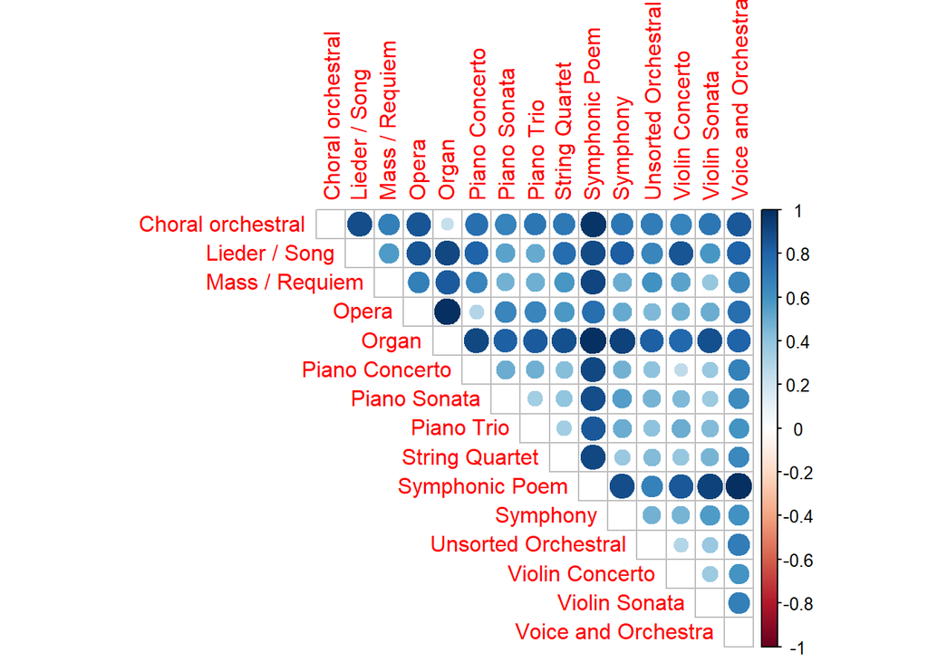

```r
library(corrplot)
delta <- data.frame(matrix(0, ncol = ncol(ct), nrow = ncol(ct)))
colnames(delta) <- colnames(ct)
rownames(delta) <- colnames(ct)

s = colSums(ct)
for (i in 1:ncol(ct)){
  for (j in 1:ncol(ct)){
    res = 0
    for (k in 1:nrow(ct)){
      res = res + abs(ct[k, i]/s[i] - ct[k, j]/s[j])
    }
    delta[i, j] = 0.5*res
  }
}

corrplot(data.matrix(delta), type="upper")
```

```r
head(delta)
```

|  | Choral orchestral | Lieder / Song | Mass / Requiem | Opera | Organ | Piano Concerto | Piano Sonata | Piano Trio | String Quartet | Symphonic Poem | Symphony | Unsorted Orchestral | Violin Concerto | Violin Sonata | Voice and Orchestra |
| --- | --- | --- | --- | --- | --- | --- | --- | --- | --- | --- | --- | --- | --- | --- | --- |
| Choral orchestral | 0.0000000 | 0.8823529 | 0.6813725 | 0.8529412 | 0.2352941 | 0.7529412 | 0.6624650 | 0.7262443 | 0.7147526 | 0.9705882 | 0.7258709 | 0.6995798 | 0.6656347 | 0.7289916 | 0.8411765 |
| Lieder / Song | 0.8823529 | 0.0000000 | 0.5620567 | 0.8574468 | 0.9090909 | 0.8074468 | 0.5336035 | 0.5008183 | 0.7669706 | 0.8936170 | 0.8215245 | 0.6546353 | 0.8521837 | 0.5858663 | 0.8085106 |
| Mass / Requiem | 0.6813725 | 0.5620567 | 0.0000000 | 0.6833333 | 0.8333333 | 0.6500000 | 0.4761905 | 0.4871795 | 0.5833333 | 0.9166667 | 0.4975728 | 0.6011905 | 0.5394737 | 0.3809524 | 0.6500000 |
| Opera | 0.8529412 | 0.8574468 | 0.6833333 | 0.0000000 | 1.0000000 | 0.3000000 | 0.6595238 | 0.6576923 | 0.5753968 | 0.7500000 | 0.5087379 | 0.4428571 | 0.4815789 | 0.4928571 | 0.7500000 |
| Organ | 0.2352941 | 0.9090909 | 0.8333333 | 1.0000000 | 0.0000000 | 0.9000000 | 0.8174603 | 0.8321678 | 0.8730159 | 1.0000000 | 0.9223301 | 0.8198052 | 0.7894737 | 0.8733766 | 0.8090909 |
| Piano Concerto | 0.7529412 | 0.8074468 | 0.6500000 | 0.3000000 | 0.9000000 | 0.0000000 | 0.4936508 | 0.4807692 | 0.4277778 | 0.9000000 | 0.4713592 | 0.4071429 | 0.2592105 | 0.3785714 | 0.6750000 |

```r
print(nrow(delta))
```

```
## [1] 15
```

```r
print(ncol(delta))
```

```
## [1] 15
```

Provedite postupak klasičnog višedimenzionalnog skaliranja. **Skicirajte** *scree plot* svojstvenih vrijednosti. Koliki broj dimenzija bi objasnio većinu varijance?

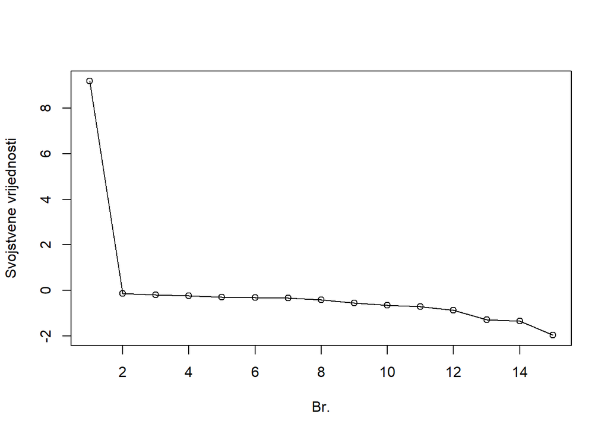

```r
eigen_dec <- eigen(delta)
Q <- eigen_dec$vectors

plot(
  x = seq(1:length(eigen_dec$values)),
  y = eigen_dec$values,
  type = "o",
  xlab = "Br.",
  ylab = "Svojstvene vrijednosti"
)
```

```r
mds <- cmdscale(delta, k=2, eig=TRUE)
x <- mds$points[,1]
y <- mds$points[,2]

print(mds$points)
```

```
##                            [,1]        [,2]
## Choral orchestral    0.50130448 -0.03025399
## Lieder / Song        0.04934133  0.01720921
## Mass / Requiem       0.01295348 -0.14140805
## Opera               -0.29540858  0.16331327
## Organ                0.67020990  0.02617709
## Piano Concerto      -0.21560021 -0.06129701
## Piano Sonata        -0.02823022 -0.13641667
## Piano Trio          -0.06786673 -0.09044597
## String Quartet      -0.13503435 -0.13007841
## Symphonic Poem      -0.01313332  0.71211081
## Symphony            -0.16084319 -0.07892842
## Unsorted Orchestral -0.11779311  0.12660707
## Violin Concerto     -0.09674155 -0.05369739
## Violin Sonata       -0.13849046 -0.13728644
## Voice and Orchestra  0.03533252 -0.18560509
```

**Prikažite** kategorije na grafu raspršenja s **dvije dimenzije** i **označite** koju kategoriju pojedina točka predstavlja. Uočavate li kakvo prirodno grupiranje kategorija?

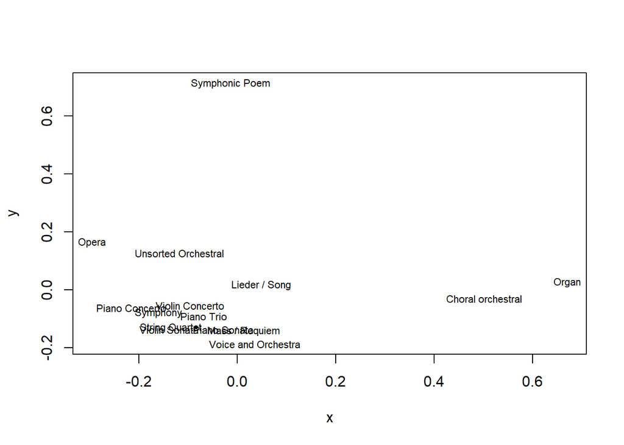

```r
plot(x, y,
     type="n"
)

text(x, y, labels = colnames(delta), cex=0.7)
```

**Prikažite** graf raspršenja za skaliranje dobiveno *Sammon* metodom i **označite** koju kategoriju pojedina točka predstavlja. Usporedite ga s gore dobivenim grafom. Kakve razlike uočavate?

```r
mds_sammon=sammon(as.matrix(delta),
    y = mds$points,
    k = 2,
    niter = 100,
    trace = TRUE,
    magic = 0.2,
    tol = 1e-4
)
```

```
## Initial stress        : 0.24896
## stress after  10 iters: 0.06062, magic = 0.461
## stress after  20 iters: 0.05530, magic = 0.500
## stress after  30 iters: 0.05431, magic = 0.500
## stress after  40 iters: 0.05412, magic = 0.500
## stress after  50 iters: 0.05408, magic = 0.500
```

```r
names(mds_sammon)
```

```
## [1] "points" "stress" "call"
```

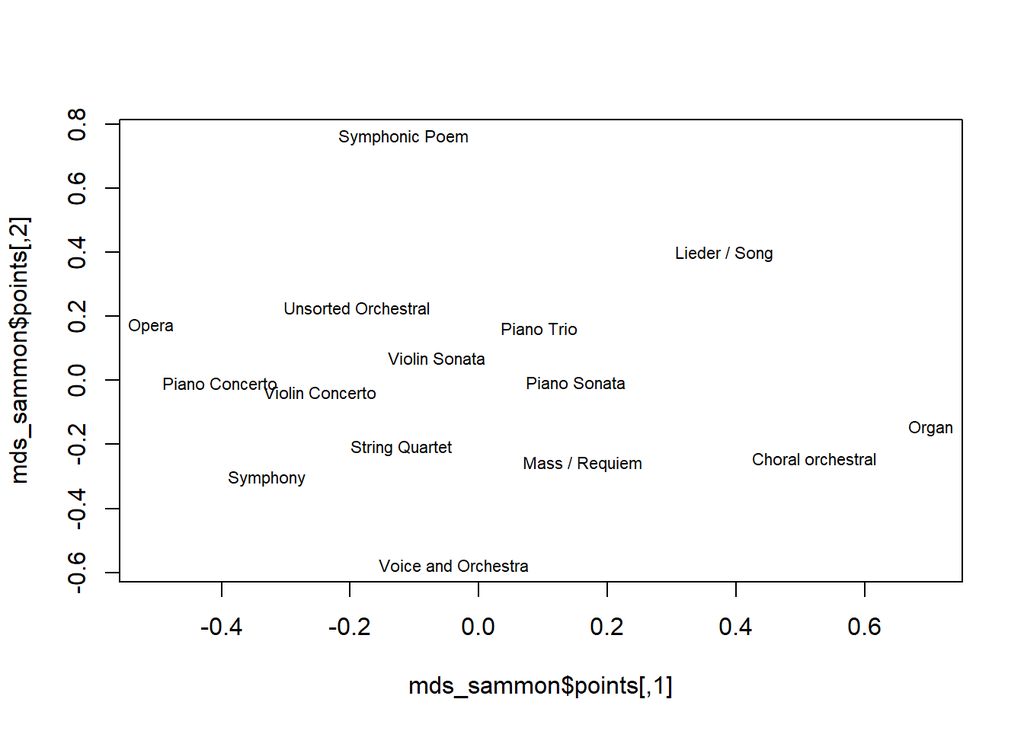

```r
x1 <- mds_sammon$points[, 1]
y1 <- mds_sammon$points[, 2]


plot(mds_sammon$points,
     type="n"
)
text(mds_sammon$points, labels = colnames(delta), cex=0.7)
```

## 3.2. Nemetričko skaliranje

Odaberite proizvoljan broj skladatelja (npr. 10–30) s **najvećim prosječnim brojem** glasova po skladbama, te **kreirajte** novi podskup podataka tako da sadrži samo skladbe tih autora.

```r
df_sub1 <- df %>% group_by(composer) %>% summarise(mean_stars = mean(stars))  %>% arrange(desc(mean_stars)) %>% top_n(15)
df_sub1 <-  df[(df$composer %in% dplyr::pull(df_sub1, composer)),]

# df_sub1 <- df_tmp %>% group_by(composer) %>% summarise(mean_stars = mean(stars))  %>% arrange(desc(mean_stars)) %>% top_n(15)
# df_sub1 <-  df_tmp[(df_tmp$composer %in% dplyr::pull(df_sub1, composer)),]

head(df_sub1)
```

|  | rank | title | composer | category | year | stars |
| --- | --- | --- | --- | --- | --- | --- |
| 1 | 1 | The Four Seasons (Le Quattro Stagioni) | Antonio Vivaldi | Violin Concerto | 1723 | 2515 |
| 2 | 2 | Requiem in D Minor, K. 626 | Wolfgang Amadeus Mozart | Mass / Requiem | 1791 | 2122 |
| 3 | 3 | Symphony No. 9 in D Minor, Op. 125 | Ludwig van Beethoven | Symphony | 1824 | 2084 |
| 4 | 4 | Nocturnes | Frédéric Chopin | Piano Sonata | 1846 | 1999 |
| 5 | 5 | Swan Lake, Op. 20 | Pyotr Ilyich Tchaikovsky | Ballet | 1876 | 1335 |
| 7 | 7 | Brandenburg Concertos, BWV 1046–1051 | Johann Sebastian Bach | Unsorted Orchestral | 1721 | 1263 |

```r
print(nrow(df_sub1))
```

```
## [1] 494
```

```r
print(ncol(df_sub1))
```

```
## [1] 6
```

U nastavku vježbe koristite ovako generirani podskup podataka.

**Definirajte** jednu proizvoljnu mjeru različitosti između dva skladatelja. Vaša mjera različitosti može uključivati npr.

- euklidsku udaljenost između broja skladbi po kategorijama,
- korelacijsku udaljenost između broja skladbi po kategorijama,
- totalnu varijacijsku udaljenost između broja skladbi po kategorijama,
- ukupan broj skladbi po pojedinoj kategoriji,
- prosječnu godinu izdanja svih skladbi,
- ukupan broj glasova po svim skladbama,
- prosječan broj glasova po svim skladbama,
- …

Pokušajte konstruirati mjeru različitosti koju ćete moći intuitivno interpretirati.

**Izračunajte** matricu različitosti za skladatelje koristeći Vašu mjeru različitosti. **Izračunajte** izometrično skaliranje i **prikažite** rezultat grafom raspršenja s **dvije dimenzije**, te **označite** koju kategoriju pojedina točka predstavlja. Možete li interpretirati dobiveni graf u skladu s korištenom mjerom različitosti?

```r
ct <- table(df_sub1$category, df_sub1$composer)

delta <- data.frame(matrix(0, ncol=ncol(ct), nrow=ncol(ct)))
colnames(delta) <- colnames(ct)

# euklidska udaljenost
s = colSums(ct)
for (i in 1:ncol(ct)){
  for (j in 1:ncol(ct)){
    res = (ct[,i] - ct[,j]) %*% (ct[,i] - ct[,j])
    delta[i, j] = res
  }
}
delta = (delta - min(delta))/(max(delta) - min(delta))

# totalna varijacijska udaljenost
#s = colSums(ct)
#for (i in 1:ncol(ct)){
#  for (j in 1:ncol(ct)){
#    res = 0
#    for (k in 1:nrow(ct)){
#      res = res + abs(ct[k, i]/s[i] - ct[k, j]/s[j])
#    }
#    delta[i, j] = 0.5*res
#  }
#}

print(delta)
```

```
##    Antonín Dvořák Antonio Vivaldi Frédéric Chopin George Frideric Handel
## 1      0.00000000      0.06384615       0.3223077             0.10846154
## 2      0.06384615      0.00000000       0.2938462             0.07230769
## 3      0.32230769      0.29384615       0.0000000             0.37538462
## 4      0.10846154      0.07230769       0.3753846             0.00000000
## 5      0.24461538      0.21000000       0.4792308             0.16846154
## 6      0.10076923      0.11846154       0.3876923             0.20000000
## 7      0.06307692      0.06692308       0.3515385             0.09307692
## 8      0.55769231      0.48615385       0.5153846             0.32461538
## 9      0.14384615      0.22307692       0.2076923             0.27076923
## 10     0.64923077      0.82230769       0.3592308             0.89615385
## 11     0.05615385      0.06461538       0.1953846             0.10769231
## 12     0.02384615      0.09076923       0.3384615             0.12615385
## 13     0.11307692      0.07692308       0.3461538             0.08923077
## 14     0.08461538      0.09307692       0.1176923             0.16538462
```

[output cut: 49 more lines]

```r
delta = data.matrix(delta)
mds_iso=isoMDS(delta, y = cmdscale(delta, 2), k=2)
```

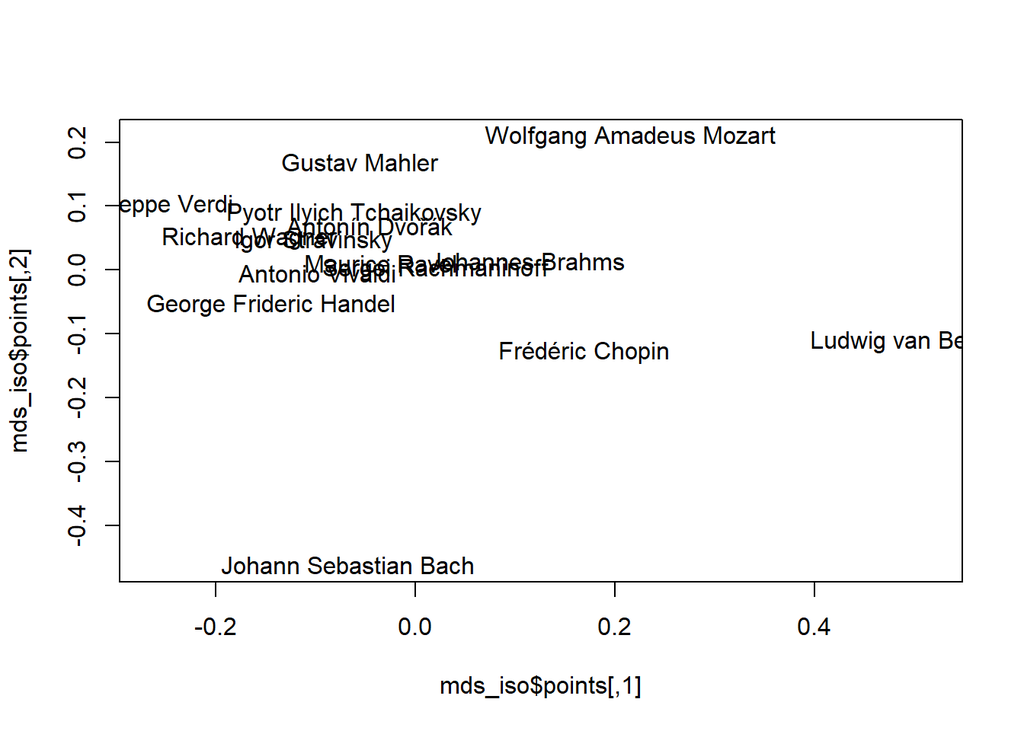

```r
plot(mds_iso$points,
     type = "n")
text(mds_iso$points, labels=colnames(delta))
```

Ponovite jednu metodu **metričkog skaliranja** po izboru (klasično ili *Sammon*), ovaj puta korištenjem proizvoljne **mjere udaljenosti** nad skladateljima (npr. euklidska/korelacijska/*totalna varijacijska* udaljenost između broja skladbi po pojedinoj kategoriji). Pokušajte odabrati mjeru udaljenosti koju ćete lakše moći interpretirati. Možete li objasniti razlike u odnosu na prethodno dobiveni graf?

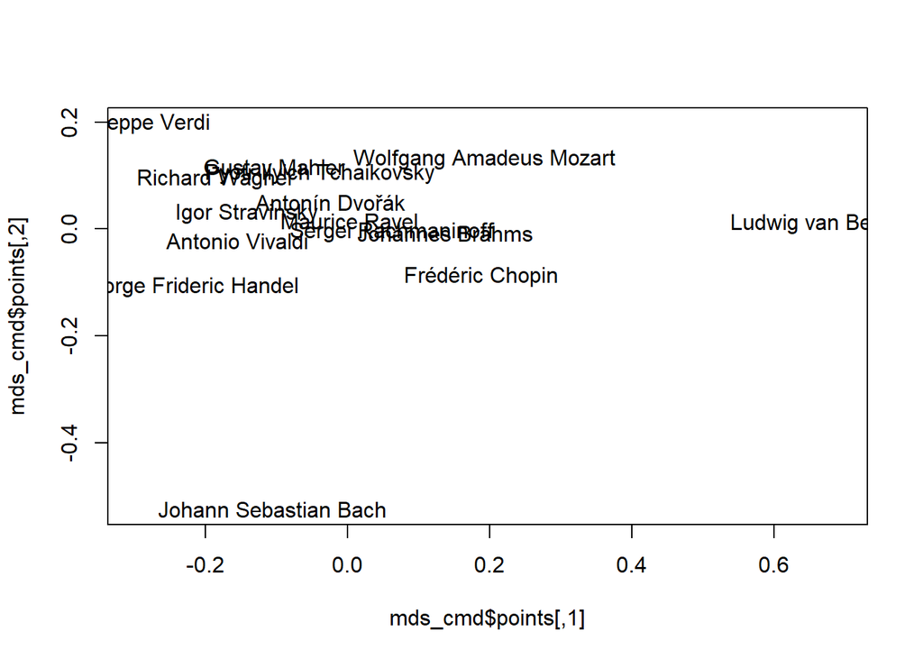

```r
mds_cmd=cmdscale(delta, eig=TRUE, k=2)
x <- mds_cmd$points[, 1]
y <- mds_cmd$points[, 2]

plot(mds_cmd$points,
     type = "n"
)
text(mds_cmd$points, labels=colnames(delta))
```

# 4. Analiza korespondencije

**Kreirajte** novi podskup podataka tako da sadrži samo skladbe **prvih 5–10 skladatelja** po nekom kriteriju — proizvoljno odaberite kriterij po kojemu ćete ih poredati (npr. ukupan broj skladbi, ukupan broj glasova po svim skladbama, prosječan broj glasova po svim skladbama…). Zatim **odredite** koje kategorije skladbi se najčešće pojavljuju u dobivenom podskupu, te unutar njega zadržite samo skladbe koje pripadaju **5–10 najčešćih kategorija**.

```r
# df_sub2 <- df_tmp %>% group_by(composer) %>% summarise(all_stars = sum(stars)) %>% arrange(desc(all_stars)) %>% top_n(5)
# l3 <- dplyr::pull(df_sub2, composer)
# df_sub2 <- df_tmp[df_tmp$composer %in% l3,]

df_sub2 <- df %>% group_by(composer) %>% summarise(all_stars = sum(stars)) %>% arrange(desc(all_stars)) %>% top_n(5)
l3 <- dplyr::pull(df_sub2, composer)
df_sub2 <- df[df$composer %in% l3,]

top_n_categories <- df_sub2 %>% count(category, sort=TRUE) %>% top_n(5)
print(top_n_categories)
```

```
##              category  n
## 1        Piano Sonata 57
## 2            Symphony 31
## 3   Choral orchestral 27
## 4      String Quartet 26
## 5      Piano Concerto 22
## 6 Unsorted Orchestral 22
```

```r
l4 <- dplyr::pull(top_n_categories, category)
df_sub2 <- df_sub2[df_sub2$category %in% l4,]
df_sub2
```

|  | rank | title | composer | category | year | stars |
| --- | --- | --- | --- | --- | --- | --- |
| 3 | 3 | Symphony No. 9 in D Minor, Op. 125 | Ludwig van Beethoven | Symphony | 1824 | 2084 |
| 7 | 7 | Brandenburg Concertos, BWV 1046–1051 | Johann Sebastian Bach | Unsorted Orchestral | 1721 | 1263 |
| 8 | 8 | Symphony No. 5 in C Minor, Op. 67 | Ludwig van Beethoven | Symphony | 1808 | 1251 |
| 10 | 10 | Symphony No. 7 in A Major, Op. 92 | Ludwig van Beethoven | Symphony | 1812 | 1101 |
| 11 | 11 | Symphony No. 40 in G Minor, K. 550 | Wolfgang Amadeus Mozart | Symphony | 1788 | 1022 |
| 20 | 20 | Piano Sonata No. 23 in F Minor (Appassionata), Op. 57 | Ludwig van Beethoven | Piano Sonata | 1805 | 831 |
| 21 | 21 | 1812 Overture, Op. 49 | Pyotr Ilyich Tchaikovsky | Unsorted Orchestral | 1880 | 825 |
| 23 | 23 | Hungarian Dances, WoO 1 | Johannes Brahms | Unsorted Orchestral | 1869 | 815 |
| 24 | 24 | Symphony No. 6 in F Major (Pastoral Symphony), Op. 68 | Ludwig van Beethoven | Symphony | 1808 | 806 |
| 25 | 25 | The Well-Tempered Clavier, BWV 846–893 | Johann Sebastian Bach | Piano Sonata | 1742 | 792 |

[output cut: 175 more lines]

U nastavku vježbe koristite ovako generirani podskup podataka.

**Izračunajte i prikažite** kontingencijsku tablicu između skladatelja i kategorije skladbi koje su napisali.

```r
ct2 <- table(df_sub2$composer, df_sub2$category)
ct2
```

```
##
##                            Choral orchestral Piano Concerto Piano Sonata
##   Johann Sebastian Bach                   23              0           11
##   Johannes Brahms                          1              2           10
##   Ludwig van Beethoven                     0              5           25
##   Pyotr Ilyich Tchaikovsky                 0              2            1
##   Wolfgang Amadeus Mozart                  3             13           10
##
##                            String Quartet Symphony Unsorted Orchestral
##   Johann Sebastian Bach                 0        0                   1
##   Johannes Brahms                       3        4                   6
##   Ludwig van Beethoven                 17        9                   3
##   Pyotr Ilyich Tchaikovsky              2        7                   6
##   Wolfgang Amadeus Mozart               4       11                   6
```

**Prikažite** graf analize korespondencije između varijabli `composer` i `category`. Obratite pozornost na ukupnu objašnjenu varijancu. Na temelju dobivenog grafa i kontingencijske tablice iz prethodnog zadatka pokušajte odgovoriti na sljedeća pitanja:

- Koji skladatelji se najviše izdvajaju po pojedinoj kategoriji?
- Koji skladatelji su određenu kategoriju skladbi pisali znatno više ili manje u usporedbi s drugim skladateljima?
- Koji skladatelji su određenu kategoriju skladbi pisali znatno više ili manje od drugih kategorija?
- Koji skladatelji su pisali prosječan broj skladbi u svim kategorijama?

```r
library(ca)
mytable <- with(df_sub2[c('composer', 'category')], ct2)
fit <- ca(mytable)
summary(fit)
```

```
##
## Principal inertias (eigenvalues):
##
##  dim    value      %   cum%   scree plot
##  1      0.540642  69.7  69.7  *****************
##  2      0.158814  20.5  90.2  *****
##  3      0.059930   7.7  97.9  **
##  4      0.016236   2.1 100.0  *
##         -------- -----
##  Total: 0.775622 100.0
##
##
## Rows:
##     name   mass  qlt  inr    k=1 cor ctr    k=2 cor ctr
## 1 | JhSB |  189  999  558 | 1511 999 799 |   30   0   1 |
## 2 | JhnB |  141  287   41 | -252 284  17 |   24   3   1 |
## 3 | LdwB |  319  990  162 | -358 325  76 | -512 664 526 |
## 4 | PyIT |   97  779  130 | -596 343  64 |  674 437 278 |
## 5 | WlAM |  254  648  109 | -308 284  45 |  348 364 194 |
##
## Columns:
##     name   mass  qlt  inr    k=1 cor ctr    k=2 cor ctr
## 1 | Chrl |  146  998  545 | 1692 989 773 |  164   9  25 |
## 2 | PnCn |  119  532  104 | -463 315  47 |  384 217 110 |
## 3 | PnSn |  308  887   57 |   35   9   1 | -355 878 244 |
## 4 | StrQ |  141  947  107 | -485 399  61 | -568 548 286 |
## 5 | Symp |  168  931   87 | -517 665  83 |  327 266 113 |
## 6 | UnsO |  119  698  101 | -402 246  36 |  544 452 222 |
```

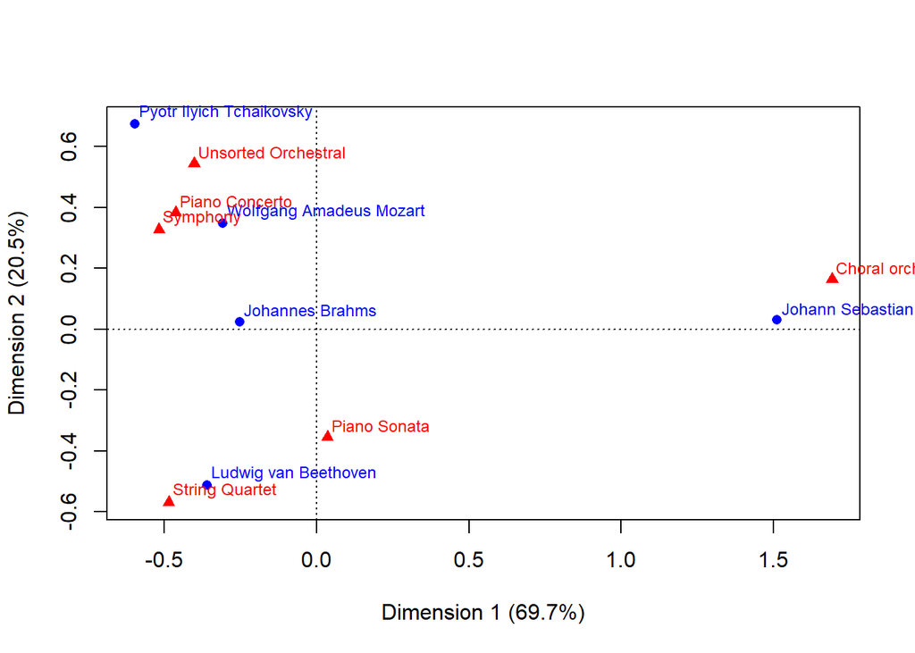

```r
plot(fit)
```

Kreirajte novi podskup podataka tako da sadrži **5–10 skladatelja po Vašem izboru**. Zatim ponovno **odredite** koje kategorije skladbi se najčešće pojavljuju u dobivenom podskupu, te zadržite samo skladbe koje pripadaju **prvih 5–10 kategorija**. **Izračunajte i prikažite** kontingencijsku matricu. **Prikažite** graf analize korespondencije. Pokušajte ponovo odgovoriti na gornja pitanja. Kakve nove zaključke možete izvesti?

```r
composers <- c('Claude Debussy', 'Richard Wagner', 'Franz Liszt', 'Edvard Grieg', 'Erik Satie')

# df_sub3 <- df_tmp[df_tmp$composer %in% composers, ]
df_sub3 <- df[df$composer %in% composers, ]

top_n_categories <- df_sub3 %>% count(category, sort=TRUE) %>% top_n(10)
print(top_n_categories)
```

```
##                         category  n
## 1                   Piano Sonata 27
## 2                          Opera 10
## 3            Unsorted Orchestral 10
## 4                  Lieder / Song  7
## 5                 Piano Concerto  5
## 6                 Symphonic Poem  5
## 7  Piano duet / Piano four hands  4
## 8                       Symphony  3
## 9                   Cello Sonata  2
## 10             Choral orchestral  2
## 11                         Organ  2
## 12                String Quartet  2
## 13              Unsorted Chamber  2
## 14                 Violin Sonata  2
```

```r
l5 <- dplyr::pull(top_n_categories, category)
df_sub3 <- df_sub3[df_sub3$category %in% l5,]
df_sub3
```

|  | rank | title | composer | category | year | stars |
| --- | --- | --- | --- | --- | --- | --- |
| 27 | 27 | Hungarian Rhapsodies, S. 244 | Franz Liszt | Piano Sonata | 1846 | 768 |
| 41 | 41 | La mer (The Sea), L. 109 | Claude Debussy | Unsorted Orchestral | 1905 | 645 |
| 68 | 68 | Der Ring des Nibelungen (The Ring of the Nibelung), WWV 86 | Richard Wagner | Opera | 1874 | 466 |
| 75 | 75 | Peer Gynt, Op. 46, 55 | Edvard Grieg | Unsorted Orchestral | 1875 | 438 |
| 79 | 79 | Nocturnes (Trois Nocturnes), L. 91 | Claude Debussy | Unsorted Orchestral | 1899 | 421 |
| 81 | 81 | Tristan und Isolde (Tristan and Isolde), WWV 90 | Richard Wagner | Opera | 1859 | 413 |
| 83 | 83 | Prélude à l'après-midi d'un faune (Prelude to the Afternoon of a Faun), L. 86 | Claude Debussy | Symphonic Poem | 1894 | 403 |
| 88 | 88 | Tannhäuser, WWV 70 | Richard Wagner | Opera | 1845 | 387 |
| 109 | 109 | Préludes, L. 117 & L.123 | Claude Debussy | Piano Sonata | 1913 | 316 |
| 114 | 114 | Piano Concerto, Op. 16 | Edvard Grieg | Piano Concerto | 1868 | 303 |

[output cut: 73 more lines]

```r
ct3 <- table(df_sub3$composer, df_sub3$category)
ct3
```

```
##
##                  Cello Sonata Choral orchestral Lieder / Song Opera Organ
##   Claude Debussy            1                 0             5     1     0
##   Edvard Grieg              1                 0             1     0     0
##   Franz Liszt               0                 2             0     0     2
##   Richard Wagner            0                 0             1     9     0
##
##                  Piano Concerto Piano duet / Piano four hands Piano Sonata
##   Claude Debussy              1                             4           12
##   Edvard Grieg                1                             0            2
##   Franz Liszt                 3                             0           13
##   Richard Wagner              0                             0            0
##
##                  String Quartet Symphonic Poem Symphony Unsorted Chamber
##   Claude Debussy              1              1        0                2
##   Edvard Grieg                1              0        0                0
##   Franz Liszt                 0              3        2                0
##   Richard Wagner              0              1        1                0
##
##                  Unsorted Orchestral Violin Sonata
##   Claude Debussy                   6             1
##   Edvard Grieg                     4             1
##   Franz Liszt                      0             0
##   Richard Wagner                   0             0
```

```r
mytable <- with(df_sub3[c('composer', 'category')], ct3)
fit <- ca(mytable)
summary(fit)
```

```
##
## Principal inertias (eigenvalues):
##
##  dim    value      %   cum%   scree plot
##  1      0.688887  55.1  55.1  **************
##  2      0.432762  34.6  89.6  *********
##  3      0.129710  10.4 100.0  ***
##         -------- -----
##  Total: 1.251358 100.0
##
##
## Rows:
##     name   mass  qlt  inr    k=1 cor ctr    k=2 cor ctr
## 1 | CldD |  422  731  131 | -331 282  67 |  418 449 170 |
## 2 | EdvG |  133  571  155 | -511 178  50 |  758 393 176 |
## 3 | FrnL |  301  994  245 | -277  75  34 | -967 918 650 |
## 4 | RchW |  145  999  469 | 2011 997 849 |  100   2   3 |
##
## Columns:
##      name   mass  qlt  inr    k=1 cor ctr     k=2 cor ctr
## 1  | CllS |   24  714   28 | -507 174   9 |   894 540  45 |
## 2  | Chrl |   24  979   45 | -334  48   4 | -1469 931 120 |
## 3  | LdrS |   84  813   34 |  -27   1   0 |   640 811  80 |
## 4  | Oper |  120 1000  445 | 2141 991 802 |   200   9  11 |
## 5  | Orgn |   24  979   45 | -334  48   4 | -1469 931 120 |
## 6  | PnCn |   60  739   28 | -403 275  14 |  -524 464  38 |
## 7  | PndP |   48  410   53 | -399 116  11 |   635 294  45 |
## 8  | PnSn |  325  940   73 | -384 527  70 |  -340 413  87 |
## 9  | StrQ |   24  714   28 | -507 174   9 |   894 540  45 |
## 10 | SymP |   60  999   27 |  205  74   4 |  -724 926  73 |
## 11 | Symp |   36  969   36 |  585 275  18 |  -929 694  72 |
## 12 | UnsC |   24  410   26 | -399 116   6 |   635 294  22 |
## 13 | UnsO |  120  891  102 | -486 222  41 |   842 669 197 |
## 14 | VlnS |   24  714   28 | -507 174   9 |   894 540  45 |
```

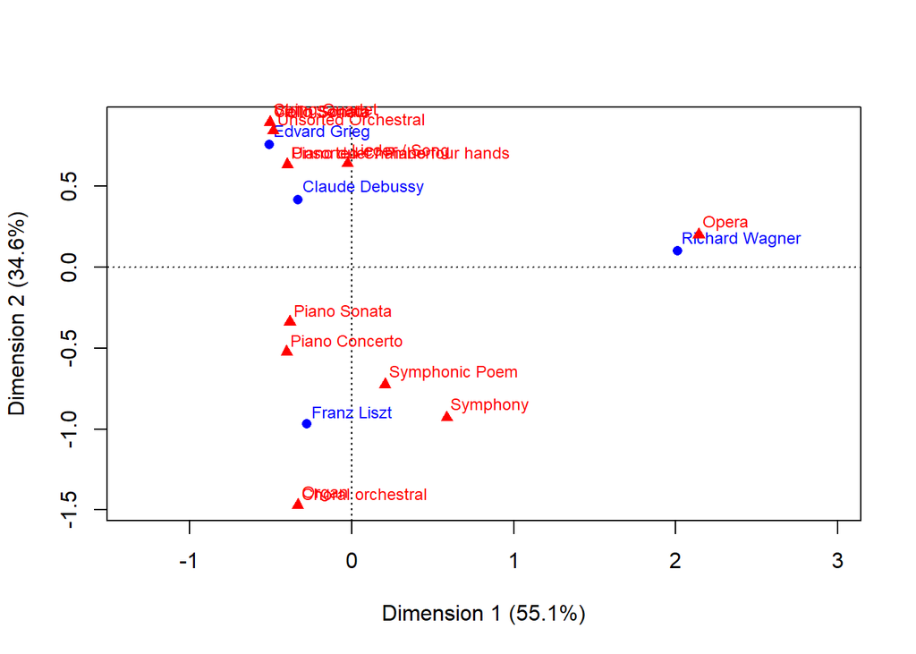

```r
plot(fit)
```